### Loading the Opinion Lexicons to Determine Sentiment

This is an essential step for sentiment analysis. These text documents from Hu and Liu, 2004* are filled with positive and negative words, respectively. The algorithm we will write next will check these documents to score each word in the tweet. If the algorithm runs across the word “love” in a tweet, it will check the positive-words.txt file, find “love” is included, and score the word with a +1. More on that in a second…

```r
lex.pos = scan('~/Desktop/R/Text_Analysis/data/opinionLexicon/positive-words.txt', what='character', comment.char = ';')
lex.neg = scan('~/Desktop/R/Text_Analysis/data/opinionLexicon/negative-words.txt', what='character', comment.char = ';')
```

Add words relevant to our corpus using the combine c() function:

```r
pos.words = c(lex.pos, 'win', 'prove', 'beat', 'endorse', 'endorses', 'exciting', 'vote', 'wins', 'support', 'supports', 'help', 'winner')
neg.words = c(lex.neg, 'lose', 'losing', 'defeat', 'halt')
```

### Implement the sentiment scoring algorithm

Here is where the magic happens - let’s create the algorithm! To begin a function which will iterate over all of the elements in the specified object, we need to give it a name - score.sentiment sounds good. First, we set the name of our function equal to function(). Then, we fill the parenthesis with our arguments. Here, we want an argument for the tweets (our data we gathered), our positive words, and our negative words.

This function takes in an argument (tweets for us), normalizes all of the text (including removing emojis which is important for tweets), splits the tweets into separate words to analyze, compares the tweet words to the positive and negative dictionaries, returns a TRUE if the word is in the dictionary and FALSE if it is not, the trues and falses are summed up for each tweet (this is the score of the tweet), and finally, the tweet’s score and its text are returned as a data frame for ease of plotting.

Hint: You may notice some odd expressions in the first few lines of the scores function: they are called regular expressions (or, regex). Regular expressions allow the user to match on certain patterns throughout the entire text. In this case, we are matching on punctuation, control characters (or invisible, non-printing characters), and digits, in the effort to strip out unnecessary characters that do not provide sentiment valence. Check out [this CRAN page](https://stat.ethz.ch/R-manual/R-devel/library/base/html/regex.html) for more information about using regex in R.

```r
score.sentiment = function(tweets, pos.words, neg.words, .progress='none')
{

  #figure out the score for each tweet specifically
  scores = laply(tweets, function(tweet, pos.words, neg.words) {
    #normalize tweet text
    tweet = gsub('[[:punct:]]', '', tweet)
    tweet = gsub('[[:cntrl:]]', '', tweet)
    tweet = gsub('\\d+', '', tweet)

    #REMOVE EMOJIS!
    tweet = iconv(tweet, "ASCII", "UTF-8", sub="")

    tweet.lower = tolower(tweet)

    #split list into separate words
    word.list = str_split(tweet.lower, '\\s+')
    words = unlist(word.list)

    #compare our words to the dictionaries of positive and negative terms using match function
    pos.matches = match(words, pos.words)
    neg.matches = match(words, neg.words)

    #match returns a position of the matched term or NA, but we just want the TRUE/FALSE, not NA
    pos.matches = !is.na(pos.matches)
    neg.matches = !is.na(neg.matches)

    #the score of each tweet is the sum of the positive matches minus the sum of the negative matches
    score = sum(pos.matches) - sum(neg.matches)

    return(score)
  }, pos.words, neg.words, .progress = .progress)

  #compile the scores and text of tweets into a data frame for plotting
  scores.df = data.frame(score=scores, text = tweets)
  return(scores.df)
}
```

#### Algorithm Testing

Whenever you create a function (or algorithm), it is best to test it on some sample data to ensure it behaves as you expect. Let’s create a sample list of emotional sentences and save it as “sample”.

```r
sample = c("This ice cream is the best! I love this flavor!",
           "I am so angry at the terrible weather today. Frustrated.",
           "Wow, spectacular, I wish I could be as perfect as you.")
```

We already did the hard part by building our score.sentiment function earlier. Here, we just need to tell the algorithm what to use as arguments! We need to put our sample data in as the “tweets” argument, pos.words as the “pos.words”" argument, and neg.words as the “neg.words” argument!

Lets also save the result of running the algorithm as an object called sample.result.

```r
sample.result = score.sentiment(sample, pos.words, neg.words)
```

Did it work?

```r
sample.result
```

```
##   score                                                     text
## 1     2          This ice cream is the best! I love this flavor!
## 2    -3 I am so angry at the terrible weather today. Frustrated.
## 3     3   Wow, spectacular, I wish I could be as perfect as you.
```

It worked! Now we can be sure our algorithm is behaving as we would expect. Lets score our Twitter data since we are confident in our function-creating abilities…

### Scoring Twitter Data

Again, we have already created our function, we just need to tell it what to analyze. We will use our [candidate].text objects as the “tweets” argument and save each as an object called [candidate].result to plot a little later.

```r
clinton.result = score.sentiment(clinton.text, pos.words, neg.words)
cruz.result = score.sentiment(cruz.text, pos.words, neg.words)
sanders.result = score.sentiment(sanders.text, pos.words, neg.words)
trump.result = score.sentiment(trump.text, pos.words, neg.words)
```

Lets peek at the results to see if it is still working…

```r
head(clinton.result)
```

```
##   score
## 1     2
## 2     0
## 3     2
## 4     2
## 5     0
## 6     0
##                                                                                                                                           text
## 1                      Coin flip "wins" by @HillaryClinton doesn't change how happy I am for @BernieSanders. #NotMeUs #FeelTheBern #Bernie2016
## 2  @JAPITTER ROFLMAAAAO!! Thanks Jeff! Coins for donors! :-) @DJROBBZ_BLOG @Teddyshouse2II @richdoll54 @YevetteEdwards @Ronc99 @HillaryClinton
## 3           @billclinton in Laconia, NH: Progressive reformers in our history like @HillaryClinton get more done #FITN https://t.co/USPhXAEdV3
## 4                                                            @CNN @HillaryClinton it looks more like fraud, winning six coin toss. Yeah right.
## 5 RT @RuFreeman: Perspective for the Dems on #IowaCaucusresults  :  ) #Bernie2016 @HillaryClinton @SenateDems @HouseDemocrats https://t.co/77…
## 6 RT @HillaryClinton: Text CONGRATS to 47246 to tell Hillary you'll be by her side for the next part of this campaign. https://t.co/FHoAPFiji8
```

```r
head(cruz.result)
```

[output not shown]

```r
head(sanders.result)
```

[output not shown]

```r
head(trump.result)
```

[output not shown]

### Plotting Twitter Data

To visualize the sentiment of these particular tweets, we will use the plotting system ggplot2 and its quick plot (qplot) functionality. The qplot function takes an object, which is the score from our tweets, then you can specify other parts of the plot. For example, we have titled our plots “Sentiment of [candidate’s twitter handle] on Twitter,” labeled the x-axis “Valence of Sentiment (Tweet Score),” and labeled the y-axis “Count (Tweets).” These were all saved as [candidate].plot objects to use later.

Below, we impose the “Black and White” theme on the plots

```r
# Plotting Twitter Data
clinton.plot = qplot(clinton.result$score, xlim=(c(-7,7)),
                     main = "Sentiment of @HillaryClinton on Twitter", xlab= "Valence of Sentiment (Tweet Score)", ylab="Count (Tweets)")
cruz.plot = qplot(cruz.result$score, xlim=(c(-7,7)),
                  main = "Sentiment of @tedcruz on Twitter", xlab= "Valence of Sentiment (Tweet Score)", ylab="Count (Tweets)")
sanders.plot = qplot(sanders.result$score, xlim=(c(-7,7)),
                     main = "Sentiment of @BernieSanders on Twitter", xlab= "Valence of Sentiment (Tweet Score)", ylab="Count (Tweets)")
trump.plot = qplot(trump.result$score, xlim=(c(-7,7)),
                   main = "Sentiment of @realDonaldTrump on Twitter", xlab= "Valence of Sentiment (Tweet Score)", ylab="Count (Tweets)")


clinton.plot = clinton.plot + theme_bw()
cruz.plot = cruz.plot + theme_bw()
sanders.plot = sanders.plot + theme_bw()
trump.plot = trump.plot + theme_bw()
```

Output each plot!

```
## stat_bin: binwidth defaulted to range/30. Use 'binwidth = x' to adjust this.
```

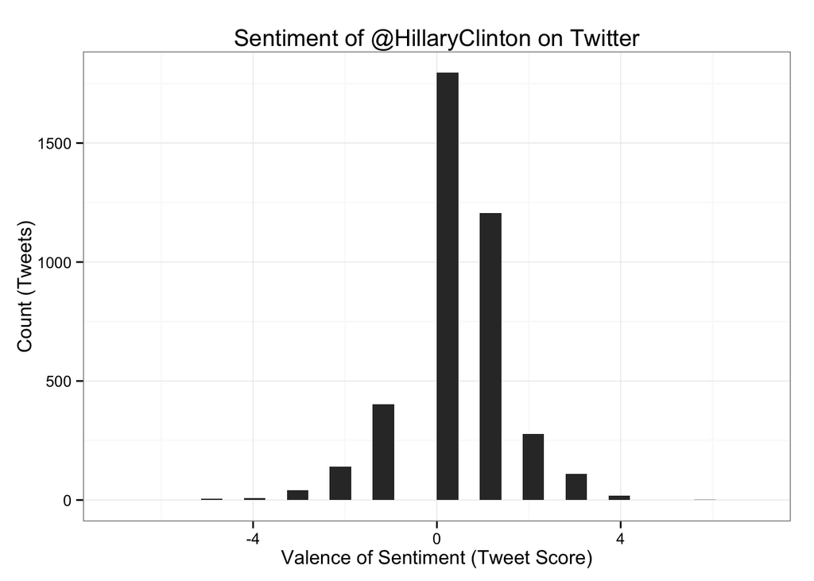

```r
clinton.plot
```

```
## stat_bin: binwidth defaulted to range/30. Use 'binwidth = x' to adjust this.
```

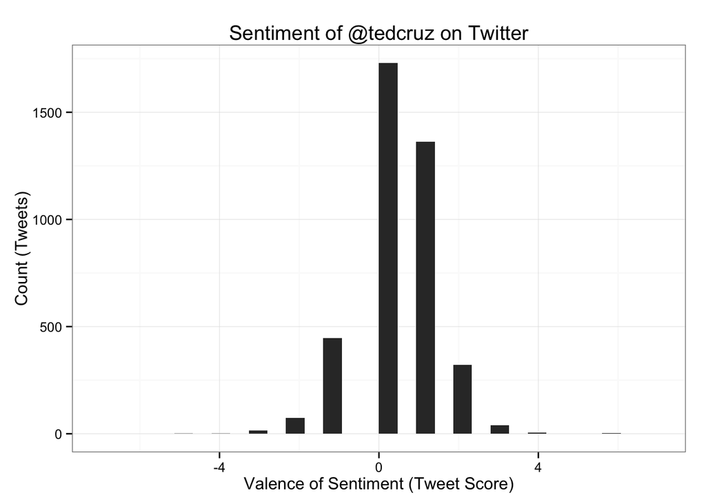

```r
cruz.plot
```

```
## stat_bin: binwidth defaulted to range/30. Use 'binwidth = x' to adjust this.
```

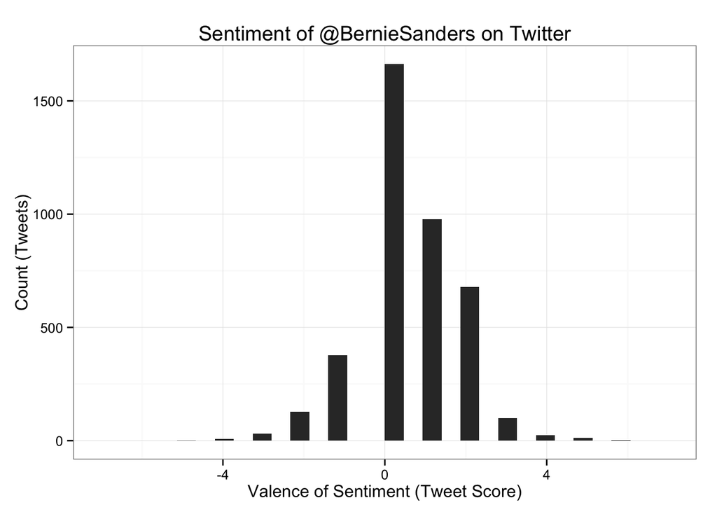

```r
sanders.plot
```

```
## stat_bin: binwidth defaulted to range/30. Use 'binwidth = x' to adjust this.
```

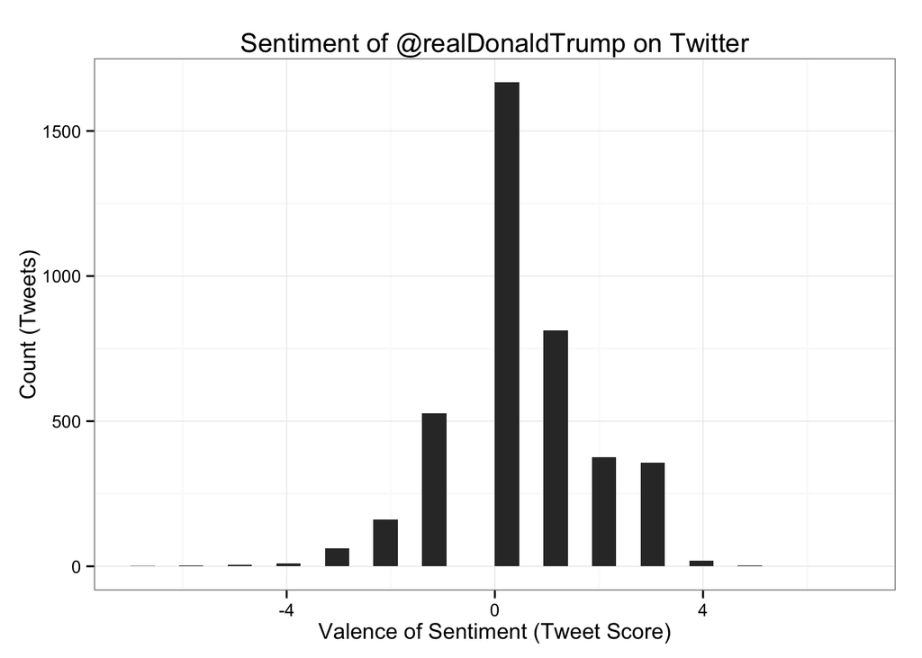

```r
trump.plot
```

#### Voila!

Acknowledgements: This algorithm was adapted from Jeffrey Breen’s Mining Twitter for Airline Consumer Sentiment article. You can find it here: http://www.inside-r.org/howto/mining-twitter-airline-consumer-sentiment.

- Liu, Minqing Hu and Junsheng Cheng. “Opinion Observer: Analyzing and Comparing Opinions on the Web.” Proceedings of the 14th International World Wide Web conference (WWW-2005), May 10-14, 2005, Chiba, Japan.